# Assignment 2, Part 2.2: Systematic interpretation of fine-mapped variants

## tl;dr

- Fine-mapped variants have higher AlphaGenome AVI PHRED scores than MAF-matched background variants: median 3.05 versus 1.74, a median difference of 1.31 (bootstrap 95% CI 1.04-1.71).
- Defining high AVI as the background 95th percentile (10.19), high scores are enriched among fine-mapped variants (odds ratio 3.98; one-sided Fisher p = 1.73 × 10^-63).
- PIP and AVI are positively but weakly related (Spearman rho = 0.159), showing that statistical fine-mapping and sequence-based prediction provide complementary rather than interchangeable evidence.
- Individual variants can therefore have concordant high PIP/high AVI evidence or high PIP/low AVI disagreement. Fine-mapping localises association signals, whereas AlphaGenome predicts molecular effects and remains model- and cell-context-dependent.

## Context & Methods

This notebook answers Q5-Q8 using the supplied `UKBB_Plt_finemapped_background_AVI.tsv`. Background variants were sampled from 1000 Genomes EUR and matched to each fine-mapped variant by minor-allele frequency, with up to five controls per fine-mapped variant.

### Key assumptions

- `AVI_PHRED` is the primary impact score because its scale is easier to compare and rank than `AVI_raw`.
- A **high AVI score** is defined before examining fine-mapped enrichment as the 95th percentile of the background AVI PHRED distribution. This operational definition marks variants more extreme than 95% of the matched background.
- The unmatched Mann-Whitney and Fisher tests describe the overall distributions. A paired Wilcoxon test comparing each fine-mapped variant with the median of its matched controls is included as the matching-aware primary sensitivity analysis.
- PIP is statistical evidence conditional on the fine-mapping model and LD; AVI is predicted molecular impact. Neither score alone proves causality or identifies the relevant cell type.
- AlphaGenome Atlas and SHAP tracks are used for hypothesis generation. SHAP attributions indicate sequence features used by the model, not experimentally verified transcription-factor binding or causal mechanisms.

```python
import sys
from pathlib import Path

import matplotlib.pyplot as plt
import numpy as np
import pandas as pd
from IPython.display import Markdown, display
from scipy import stats


def find_course_root() -> Path:
  for candidate in (Path.cwd(), *Path.cwd().parents):
    if (candidate / "data/assignment02/p02/UKBB_Plt_finemapped_background_AVI.tsv").is_file():
      return candidate
  raise FileNotFoundError("Run this notebook from within 26B1_advBioinfNGS.")


COURSE_ROOT = find_course_root()
REPOSITORY_ROOT = COURSE_ROOT.parent
sys.path.insert(0, str(REPOSITORY_ROOT))

from conf.plot_config import (  # noqa: E402
  BRAND_ACCENT,
  BRAND_DEEP,
  BRAND_STRONG,
  PLOT_COLORS,
  PLOT_FONT_FAMILY,
  apply_plot_style,
)

DATA_PATH = COURSE_ROOT / "data/assignment02/p02/UKBB_Plt_finemapped_background_AVI.tsv"
RANDOM_SEED = 20260924
BOOTSTRAP_REPEATS = 10_000
```

## Data

```python
data = pd.read_csv(DATA_PATH, sep="\t", na_values=["", '""'])
required_columns = {
  "variant_hg38", "rsID", "group", "PIP", "MAF", "matched_to",
  "AVI_raw", "AVI_PHRED",
}
assert required_columns <= set(data.columns)
assert set(data["group"].dropna().unique()) == {"finemapped", "background"}

fine = data.loc[data["group"] == "finemapped"].copy()
background = data.loc[data["group"] == "background"].copy()
assert fine["PIP"].notna().all()
assert background["PIP"].isna().all()
assert background["matched_to"].notna().all()

pd.DataFrame({
  "group": ["Fine-mapped", "Background"],
  "variants": [len(fine), len(background)],
  "non-missing AVI PHRED": [fine["AVI_PHRED"].notna().sum(), background["AVI_PHRED"].notna().sum()],
  "median MAF": [fine["MAF"].median(), background["MAF"].median()],
})
```

|  | group | variants | non-missing AVI PHRED | median MAF |
| --- | --- | --- | --- | --- |
| 0 | Fine-mapped | 1844 | 1844 | 0.265408 |
| 1 | Background | 9196 | 9196 | 0.265408 |

## Results

### Q5. AVI distribution and high-score enrichment

```python
fine_scores = fine["AVI_PHRED"].dropna().to_numpy(dtype=float)
background_scores = background["AVI_PHRED"].dropna().to_numpy(dtype=float)
high_avi_threshold = float(np.quantile(background_scores, 0.95))

rng = np.random.default_rng(RANDOM_SEED)
bootstrap_differences = np.empty(BOOTSTRAP_REPEATS)
for index in range(BOOTSTRAP_REPEATS):
  bootstrap_differences[index] = (
    np.median(rng.choice(fine_scores, len(fine_scores), replace=True))
    - np.median(rng.choice(background_scores, len(background_scores), replace=True))
  )
bootstrap_ci = np.quantile(bootstrap_differences, [0.025, 0.975])

mann_whitney = stats.mannwhitneyu(
  fine_scores, background_scores, alternative="greater"
)
fine_high = int(np.sum(fine_scores >= high_avi_threshold))
background_high = int(np.sum(background_scores >= high_avi_threshold))
enrichment_table = np.array([
  [fine_high, len(fine_scores) - fine_high],
  [background_high, len(background_scores) - background_high],
])
odds_ratio, fisher_p = stats.fisher_exact(enrichment_table, alternative="greater")

matched_background = background.groupby("matched_to")["AVI_PHRED"].median()
paired = fine.set_index("rsID")[["AVI_PHRED"]].rename(columns={"AVI_PHRED": "fine"})
paired["matched_background_median"] = matched_background
paired = paired.dropna()
matched_wilcoxon = stats.wilcoxon(
  paired["fine"], paired["matched_background_median"], alternative="greater"
)

q5_results = pd.DataFrame({
  "Measure": [
    "Fine-mapped AVI PHRED median",
    "Background AVI PHRED median",
    "Median difference (fine - background)",
    "Bootstrap 95% CI for median difference",
    "One-sided Mann-Whitney p",
    "High-AVI threshold (background p95)",
    "High-AVI fraction, fine-mapped",
    "High-AVI fraction, background",
    "High-AVI odds ratio",
    "One-sided Fisher p",
    "Matched-pair Wilcoxon p",
  ],
  "Value": [
    f"{np.median(fine_scores):.3f}",
    f"{np.median(background_scores):.3f}",
    f"{np.median(fine_scores) - np.median(background_scores):.3f}",
    f"[{bootstrap_ci[0]:.3f}, {bootstrap_ci[1]:.3f}]",
    f"{mann_whitney.pvalue:.3e}",
    f"{high_avi_threshold:.3f}",
    f"{fine_high / len(fine_scores):.1%} ({fine_high}/{len(fine_scores)})",
    f"{background_high / len(background_scores):.1%} ({background_high}/{len(background_scores)})",
    f"{odds_ratio:.3f}",
    f"{fisher_p:.3e}",
    f"{matched_wilcoxon.pvalue:.3e}",
  ],
})
q5_results
```

|  | Measure | Value |
| --- | --- | --- |
| 0 | Fine-mapped AVI PHRED median | 3.054 |
| 1 | Background AVI PHRED median | 1.743 |
| 2 | Median difference (fine - background) | 1.311 |
| 3 | Bootstrap 95% CI for median difference | [1.040, 1.715] |
| 4 | One-sided Mann-Whitney p | 9.098e-43 |
| 5 | High-AVI threshold (background p95) | 10.188 |
| 6 | High-AVI fraction, fine-mapped | 17.4% (320/1844) |
| 7 | High-AVI fraction, background | 5.0% (461/9196) |
| 8 | High-AVI odds ratio | 3.979 |
| 9 | One-sided Fisher p | 1.726e-63 |
| 10 | Matched-pair Wilcoxon p | 3.405e-72 |

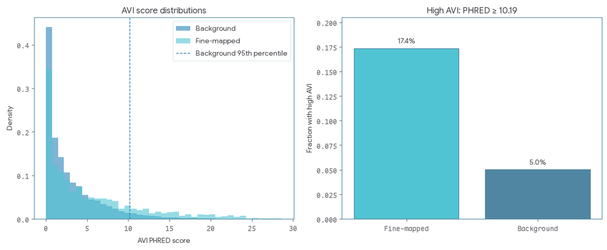

```python
figure, axes = plt.subplots(1, 2, figsize=(12, 5))
bins = np.linspace(float(data["AVI_PHRED"].min()), float(data["AVI_PHRED"].max()), 40)
axes[0].hist(
  background_scores, bins=bins, density=True, alpha=0.60,
  color=PLOT_COLORS[0], label="Background",
)
axes[0].hist(
  fine_scores, bins=bins, density=True, alpha=0.60,
  color=PLOT_COLORS[1], label="Fine-mapped",
)
axes[0].axvline(
  high_avi_threshold, color=BRAND_STRONG, linestyle="--", linewidth=1,
  label="Background 95th percentile",
)
axes[0].set_xlabel("AVI PHRED score")
axes[0].set_ylabel("Density")
axes[0].set_title("AVI score distributions")
apply_plot_style(axes[0])
axes[0].legend(prop={"family": PLOT_FONT_FAMILY})

high_fractions = [fine_high / len(fine_scores), background_high / len(background_scores)]
axes[1].bar(
  ["Fine-mapped", "Background"], high_fractions,
  color=[BRAND_ACCENT, BRAND_DEEP], edgecolor=BRAND_DEEP,
)
for x_position, fraction in enumerate(high_fractions):
  axes[1].text(
    x_position, fraction + 0.005, f"{fraction:.1%}", ha="center",
    fontfamily=PLOT_FONT_FAMILY,
  )
axes[1].set_ylim(0, max(high_fractions) * 1.18)
axes[1].set_ylabel("Fraction with high AVI")
axes[1].set_title(f"High AVI: PHRED ≥ {high_avi_threshold:.2f}")
apply_plot_style(axes[1])
figure.tight_layout()
plt.show()
```

**Q5 interpretation.** Fine-mapped variants have a higher AVI distribution than their MAF-matched background. The median difference and both the overall and matched analyses are highly significant. High AVI is also over-represented among fine-mapped variants. Matching on MAF reduces one important confounder, but the result remains an association between variant sets and predictions; it does not validate every high-scoring variant experimentally.

### Q6. Relationship between PIP and AVI

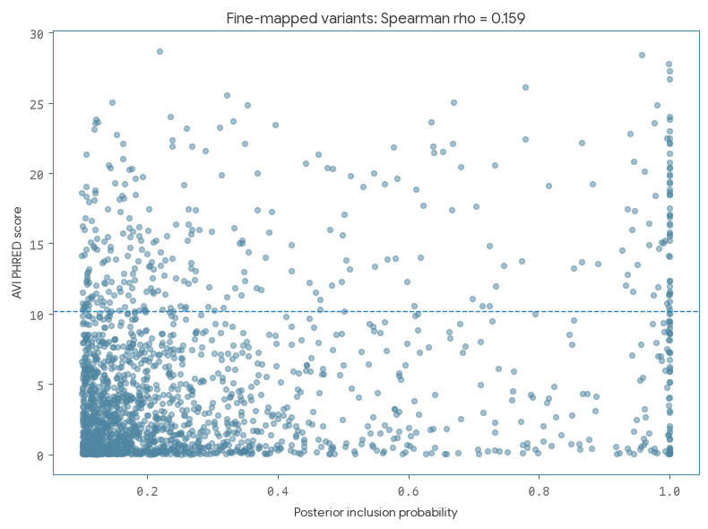

|  | Correlation | Coefficient | p-value |
| --- | --- | --- | --- |
| 0 | Spearman | 0.158611 | 7.393810e-12 |
| 1 | Pearson | 0.270789 | 2.361229e-32 |

```python
pip_avi = fine[["rsID", "PIP", "AVI_PHRED"]].dropna()
spearman = stats.spearmanr(pip_avi["PIP"], pip_avi["AVI_PHRED"])
pearson = stats.pearsonr(pip_avi["PIP"], pip_avi["AVI_PHRED"])

figure, axes = plt.subplots(figsize=(8, 6))
axes.scatter(
  pip_avi["PIP"], pip_avi["AVI_PHRED"], s=18, alpha=0.50,
  color=BRAND_DEEP,
)
axes.axhline(high_avi_threshold, color=BRAND_STRONG, linestyle="--", linewidth=1)
axes.set_xlabel("Posterior inclusion probability")
axes.set_ylabel("AVI PHRED score")
axes.set_title(f"Fine-mapped variants: Spearman rho = {spearman.statistic:.3f}")
apply_plot_style(axes)
figure.tight_layout()
plt.show()

pd.DataFrame({
  "Correlation": ["Spearman", "Pearson"],
  "Coefficient": [spearman.statistic, pearson.statistic],
  "p-value": [spearman.pvalue, pearson.pvalue],
})
```

**Q6 interpretation.** The positive relationship is statistically clear because the dataset is large, but its magnitude is weak. PIP ranks variants by compatibility with an association signal and LD model, whereas AVI ranks predicted molecular disruption from sequence. The low correlation is therefore expected and useful: the scores contribute different evidence. It also warns against treating either a high PIP or a high AVI score as sufficient evidence of causality.

### Q7. Examples where statistical and functional evidence agree or disagree

```python
high_pip_threshold = float(fine["PIP"].quantile(0.90))
low_avi_threshold = float(np.median(background_scores))
examples = fine.loc[
  (fine["PIP"] >= high_pip_threshold)
  & ((fine["AVI_PHRED"] >= high_avi_threshold) | (fine["AVI_PHRED"] <= low_avi_threshold))
].copy()
examples["evidence_pattern"] = np.where(
  examples["AVI_PHRED"] >= high_avi_threshold,
  "high PIP / high AVI",
  "high PIP / low AVI",
)
examples["Atlas"] = examples["variant_hg38"].map(
  lambda variant: "https://deepmind.google.com/science/alphagenome/atlas?q="
  + variant.replace(":", "%3A").replace(">", "%3E")
  + "&m=variant"
)
selected_examples = (
  examples.sort_values(["evidence_pattern", "PIP"], ascending=[True, False])
  .groupby("evidence_pattern", sort=False)
  .head(5)
)
selected_examples[[
  "evidence_pattern", "rsID", "variant_hg38", "PIP", "AVI_PHRED", "Atlas"
]]
```

|  | evidence_pattern | rsID | variant_hg38 | PIP | AVI_PHRED | Atlas |
| --- | --- | --- | --- | --- | --- | --- |
| 89 | high PIP / high AVI | rs10886430 | chr10:119250744:A>G | 1.0 | 15.52545 | https://deepmind.google.com/science/alphagenom... |
| 143 | high PIP / high AVI | rs111527738 | chr21:34887027:A>G | 1.0 | 20.39798 | https://deepmind.google.com/science/alphagenom... |
| 195 | high PIP / high AVI | rs113736796 | chr12:47819937:C>G | 1.0 | 20.77344 | https://deepmind.google.com/science/alphagenom... |
| 201 | high PIP / high AVI | rs114266592 | chr2:234981357:T>C | 1.0 | 11.59876 | https://deepmind.google.com/science/alphagenom... |
| 204 | high PIP / high AVI | rs114694170 | chr5:88884379:T>C | 1.0 | 12.34357 | https://deepmind.google.com/science/alphagenom... |
| 110 | high PIP / low AVI | rs10974808 | chr9:4840380:A>G | 1.0 | 0.09882 | https://deepmind.google.com/science/alphagenom... |
| 522 | high PIP / low AVI | rs1569419 | chr1:3080038:T>C | 1.0 | 0.44646 | https://deepmind.google.com/science/alphagenom... |
| 941 | high PIP / low AVI | rs3809114 | chr12:57454856:G>A | 1.0 | 0.13019 | https://deepmind.google.com/science/alphagenom... |
| 1120 | high PIP / low AVI | rs529153205 | chr20:26221066:G>C | 1.0 | 0.37898 | https://deepmind.google.com/science/alphagenom... |
| 1279 | high PIP / low AVI | rs62160676 | chr2:111410354:T>C | 1.0 | 0.07078 | https://deepmind.google.com/science/alphagenom... |

```python
lines = ["Selected AlphaGenome Atlas links:"]
for row in selected_examples.itertuples(index=False):
  lines.append(
    f"- **{row.rsID}** ({row.evidence_pattern}; PIP {row.PIP:.3f}, "
    f"AVI PHRED {row.AVI_PHRED:.2f}): [open Atlas]({row.Atlas})"
  )
display(Markdown("\n".join(lines)))
```

Selected AlphaGenome Atlas links:

- **rs10886430** (high PIP / high AVI; PIP 1.000, AVI PHRED 15.53): [open Atlas](https://deepmind.google.com/science/alphagenome/atlas?q=chr10%3A119250744%3AA%3EG&m=variant)

- **rs111527738** (high PIP / high AVI; PIP 1.000, AVI PHRED 20.40): [open Atlas](https://deepmind.google.com/science/alphagenome/atlas?q=chr21%3A34887027%3AA%3EG&m=variant)

- **rs113736796** (high PIP / high AVI; PIP 1.000, AVI PHRED 20.77): [open Atlas](https://deepmind.google.com/science/alphagenome/atlas?q=chr12%3A47819937%3AC%3EG&m=variant)

- **rs114266592** (high PIP / high AVI; PIP 1.000, AVI PHRED 11.60): [open Atlas](https://deepmind.google.com/science/alphagenome/atlas?q=chr2%3A234981357%3AT%3EC&m=variant)

- **rs114694170** (high PIP / high AVI; PIP 1.000, AVI PHRED 12.34): [open Atlas](https://deepmind.google.com/science/alphagenome/atlas?q=chr5%3A88884379%3AT%3EC&m=variant)

- **rs10974808** (high PIP / low AVI; PIP 1.000, AVI PHRED 0.10): [open Atlas](https://deepmind.google.com/science/alphagenome/atlas?q=chr9%3A4840380%3AA%3EG&m=variant)

- **rs1569419** (high PIP / low AVI; PIP 1.000, AVI PHRED 0.45): [open Atlas](https://deepmind.google.com/science/alphagenome/atlas?q=chr1%3A3080038%3AT%3EC&m=variant)

- **rs3809114** (high PIP / low AVI; PIP 1.000, AVI PHRED 0.13): [open Atlas](https://deepmind.google.com/science/alphagenome/atlas?q=chr12%3A57454856%3AG%3EA&m=variant)

- **rs529153205** (high PIP / low AVI; PIP 1.000, AVI PHRED 0.38): [open Atlas](https://deepmind.google.com/science/alphagenome/atlas?q=chr20%3A26221066%3AG%3EC&m=variant)

- **rs62160676** (high PIP / low AVI; PIP 1.000, AVI PHRED 0.07): [open Atlas](https://deepmind.google.com/science/alphagenome/atlas?q=chr2%3A111410354%3AT%3EC&m=variant)

**Q7 interpretation.** High PIP/high AVI variants are supported by both association-based localisation and a predicted sequence effect, so they are efficient candidates for Atlas track and SHAP review. A localised SHAP signal near the altered base can suggest which sequence motif or regulatory feature drives the prediction, but motif identity and direction must be checked against the relevant blood-cell track.

High PIP/low AVI variants can arise when the variant tags a causal allele through LD, when the effect involves a cell state or assay not represented strongly by the AVI aggregation, when the relevant mechanism is not well captured by the sequence model, or when the fine-mapping model is misspecified. Conversely, a high AVI score with weak PIP can mark a genuinely functional variant unrelated to the platelet association. Atlas/SHAP inspection can refine hypotheses, but experimental assays are needed to distinguish these explanations.

### Q8. Overall value and limitations

Combining fine-mapping with sequence-based prediction is valuable because the methods answer complementary questions. Fine-mapping uses association strength and LD to narrow the variants statistically compatible with a causal signal. AlphaGenome adds a mechanistic prior by identifying alleles predicted to alter molecular phenotypes and by exposing cell-type and feature-level tracks for follow-up. Concordant evidence can reduce a long credible set to a smaller experimental shortlist, while discordance reveals uncertainty that would be hidden by either score alone.

The combination also has important limitations. Fine-mapping depends on correctly matched LD, ancestry, allele orientation, sample size, and model assumptions. AVI and SHAP are model predictions affected by training data, assay coverage, aggregation across tracks, and incomplete representation of developmental or stimulated cell states. The two scores are not independent proof, neither establishes the target gene or causal cell type, and predicted effect magnitude does not necessarily equal phenotypic effect magnitude. The best use is therefore prioritisation followed by colocalisation, cell-type-specific chromatin or expression evidence, and allele-specific or CRISPR validation.

## Takeaways

1. Fine-mapped platelet-count variants are enriched for stronger AlphaGenome predictions even after MAF matching.
2. The weak PIP-AVI correlation shows that statistical and functional scores are complementary.
3. Concordant high/high variants are sensible first-pass experimental candidates; discordant variants remain informative and should not be discarded automatically.
4. Atlas tracks and SHAP attributions generate testable mechanistic hypotheses, but they do not replace blood-lineage-specific experimental validation.

**Source:** `data/assignment02/p02/UKBB_Plt_finemapped_background_AVI.tsv`, supplied with Assignment 2 Part 2.